# 2020 U.S. Presidential Election Results: Map of Electoral Votes

Author

Gaston Sanchez

Published

June 3, 2025

# 1 Description

The data visualization of this module is based on the map of electoral votes that appears in the following New York Times webpage (Nov 3, 2020):

**Presidential Election Results 2020**

https://www.nytimes.com/interactive/2020/11/03/us/elections/results-president.html

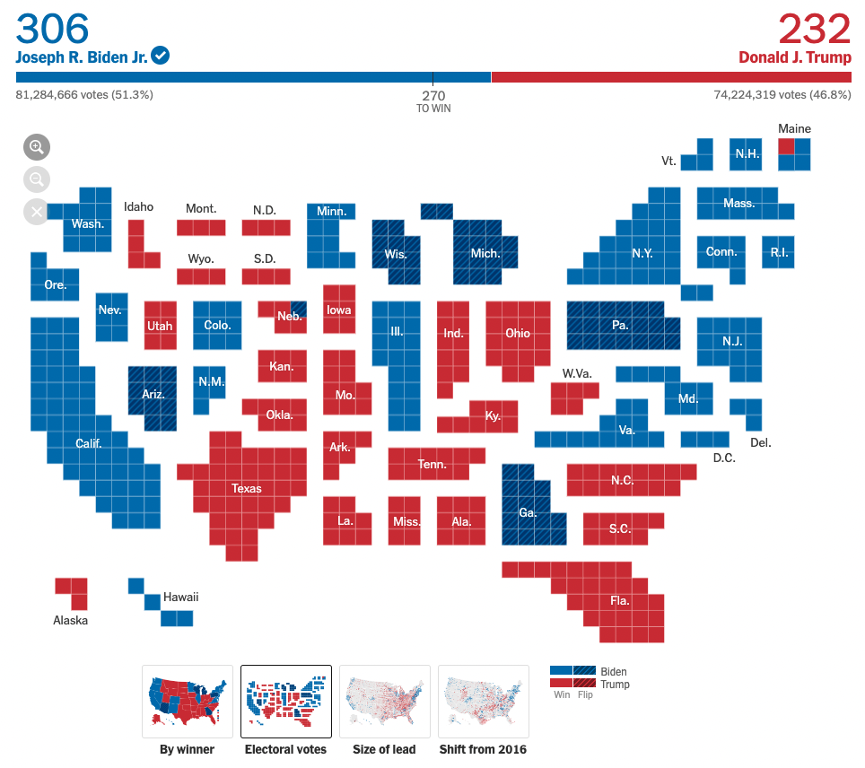

2020 Presidential Election Results: Map of Electoral Votes

## 1.1 Details (datasheet)

- **Topic(s)**:
  - Politics
  - Elections
  - President
  - U.S.
- **Data**:
  - Size: medium data
  - Format: data in CSV tables
  - Requires merging data
- **Graphic**:
  - Type: tiles plot
  - Styles: ggplot, interactive ggiraph
  - Interactive: yes

## 1.2 R Packages

```r
library(tidyverse) # ecosystem of data science packages
```

# 2 Data

This modules requires importing three data sets (each data is in a CSV file stored in the `data/` folder of this github repo):

1. `countypres_2000-2020.csv`
2. `electoral-votes-tiles-map.csv`
3. `states-lables-coords.csv`

## 2.1 Presidential Elections data

First we import the Presidential Election Returns 2000-2020 data. Keep in mind that we are only interested in the 2020 elections. Also, because the data has votes at the county level, we need to compute the total number of votes for each candidate by state, and determine the winner party.

```r
# data of presidential results (2000-2020)
pres_results = read_csv("data/countypres_2000-2020.csv")
# party winner in every state, 2020
state_by_party = pres_results |>
  filter(year == 2020) |>
  group_by(state_po, party) |>
  summarize(votes = sum(candidatevotes)) |>
  slice_max(votes) |>
  select(state_po, party)
head(state_by_party)
```

```
# A tibble: 6 × 2
# Groups:   state_po [6]
  state_po party
  <chr>    <chr>
1 AK       REPUBLICAN
2 AL       REPUBLICAN
3 AR       REPUBLICAN
4 AZ       DEMOCRAT
5 CA       DEMOCRAT
6 CO       DEMOCRAT
```

## 2.2 Import data of tiles map

The next two data sets to be imported have to do with: 1) the table that encodes the tiles for mapping the electoral votes, and 2) the table that has the coordinates for displaying the labels of the States.

```r
tiles_map = read_csv("data/electoral-votes-tiles-map.csv")

state_labels = read_csv("data/states-labels-coords.csv")
```

It should be noticed that `electoral-votes-tiles-map.csv` has the following six variables:

- `x`: x-axis coordinate
- `y`: y-axis coordinate
- `cell`: number of cell (or tile)
- `state`: name of State that a specific tile belongs to
- `abbr`: 2-letter abbreviation of a State
- `fips`: *Federal Information Processing Standard* (FIPS) code of a State

## 2.3 Merging Votes-data with Tiles-data

In order to graph the tiles map, first we need to merge the `tiles_map` table with the `state_by_party` table, matching columns `"abbr"` with “`state_po"`. Also, because the states of Maine and Nebraska split their electoral vote, we need to assign a Republican vote for Maine, and a Democrat vote for Nebraska.

```r
# merging tiles map data with winner party
tiles_map = tiles_map |>
  inner_join(state_by_party, by = c("abbr" = "state_po"))

# Maine and Nebraska have independent electoral votes
tiles_map$party[tiles_map$cell == 1487] = "REPUBLICAN"  # Maine
tiles_map$party[tiles_map$cell == 977] = "DEMOCRAT"  # Nebraska
```

# 3 Graphics

Recall that the `tiles_map` data frame has the data to graph the electoral votes map. To plot this map with `ggplot()` all you have to do is add a `geom_tile()` layer, hence the name *tiles map*.

## 3.1 Map 1

Let’s start with a basic graph of the tiles map, plotting the tiles that correspond to each state.

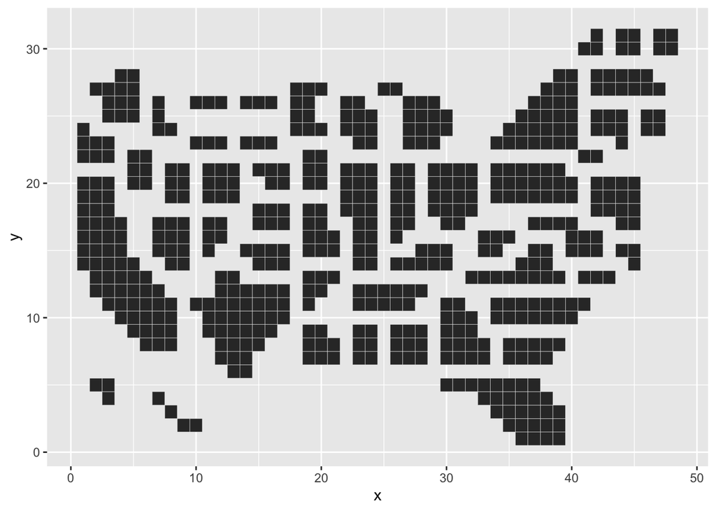

```r
ggplot(tiles_map, aes(x = x, y = y)) +
  geom_tile(color = "white")
```

## 3.2 Map 2

Because `tiles_map` has been merged with `state_by_party`, we also have the winner `party` of each state. Therefore, we can *map* this variable to the `fill` aesthetic to color-code the tiles according to party

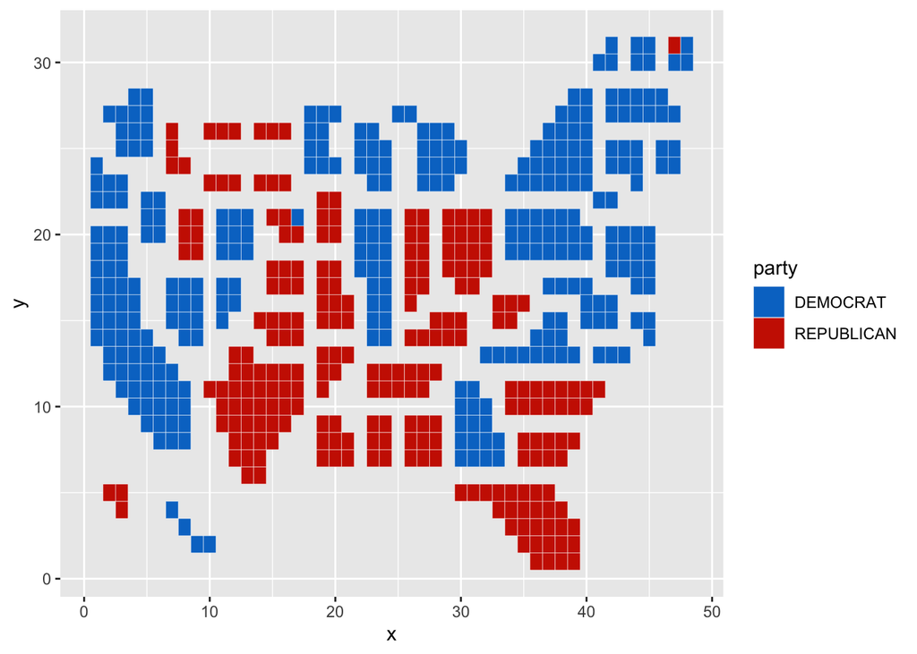

```r
ggplot(tiles_map, aes(x = x, y = y)) +
  geom_tile(color = "white", aes(fill = party)) +
  scale_fill_manual(values = c("#0077cc", "#cc2200"))
```

## 3.3 Map 3

In the third iteration of the map, we simplify the background theme and we also superimpose the names of the states that are in the table `state_labels`

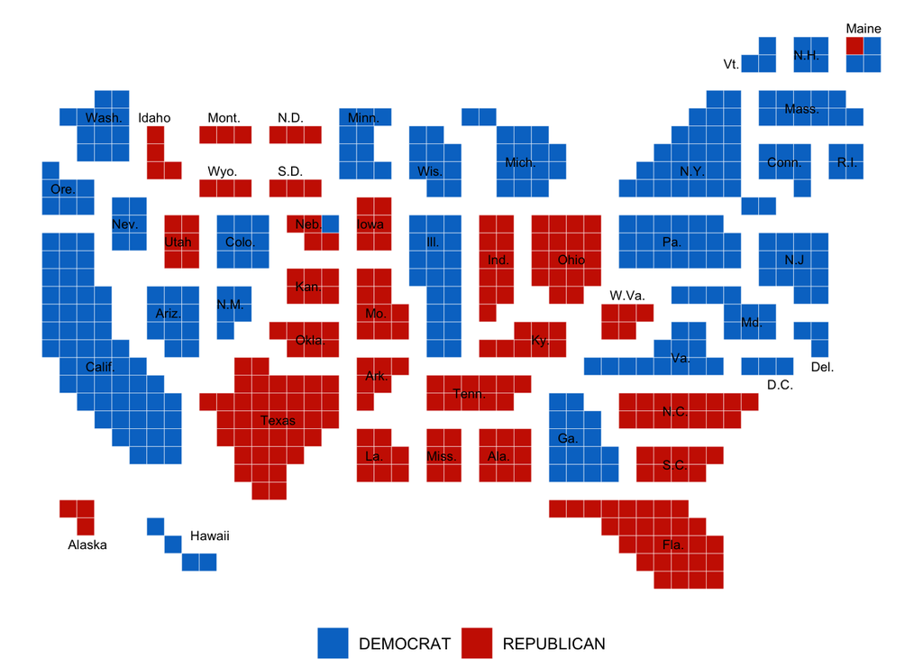

```r
ggplot(tiles_map, aes(x = x, y = y)) +
  geom_tile(color = "white", aes(fill = party)) +
  scale_fill_manual(values = c("#0077cc", "#cc2200")) +
  geom_text(data = state_labels,
            aes(x = x, y = y, label = name),
            hjust = 0, size = 2.5) +
  theme_void() +
  theme(legend.position = "bottom",
        legend.title = element_blank())
```

## 3.4 Map4

The last step involves computing the proportion of electoral votes won by each party, so that a segment horizontal bar can be displayed on top of the map to depict which party is the winner:

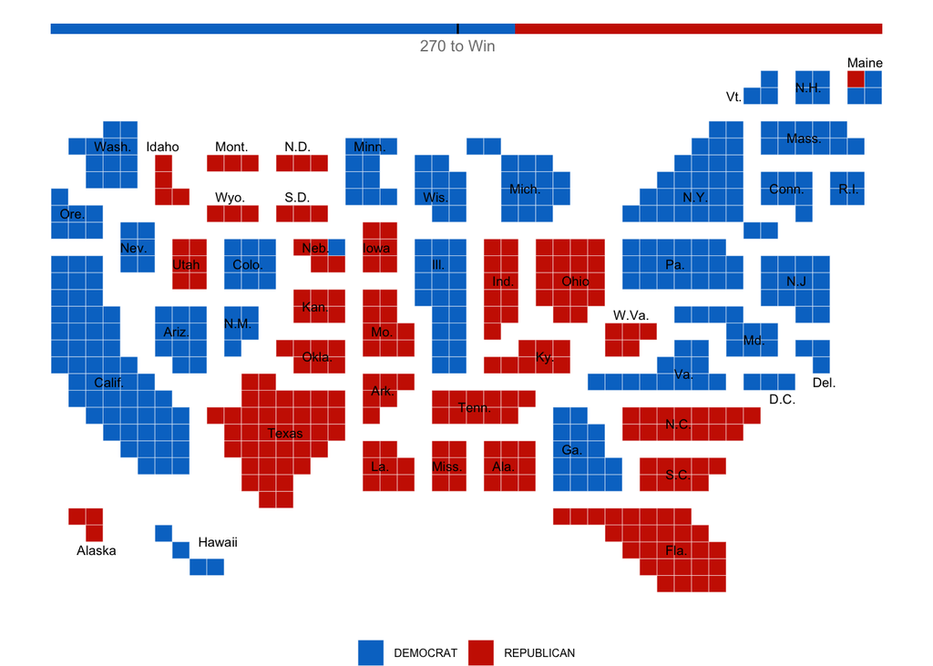

```r
# how many electoral votes
electoral_votes_by_state = tiles_map |>
  filter(state != "none") |>
  count(state, party, name = "count")

# electoral_votes_by_state |>
#   group_by(party) |>
#   summarize(total = sum(count)) |>
#   mutate(prop = total / sum(total))

# find proportions of electoral votes in terms of
# line segment to be added on top of map
# 48 * c(0.569, 0.431)


ggplot(tiles_map, aes(x = x, y = y)) +
  xlim(0, 49) +
  ylim(0, 34) +
  geom_tile(color = "white", aes(fill = party)) +
  scale_fill_manual(values = c("#0077cc", "#cc2200")) +
  geom_text(data = state_labels,
            aes(x = x, y = y, label = name),
            hjust = 0, size = 2.5) +
  geom_segment(x = 0.5, xend = 27.312, y = 34 , yend = 34,
               color = "#0077cc", linewidth = 2.5) +
  geom_segment(x = 27.312, xend = 48.5, y = 34 , yend = 34,
               color = "#cc2200", linewidth = 2.5) +
  geom_segment(x = 23.95, xend = 24.05, y = 34 , yend = 34,
               color = "black", linewidth = 2.5) +
  annotate(geom = "text", x = 24, y = 33, label = "270 to Win",
           size = 3, color = "gray50") +
  theme_void() +
  theme(legend.position = "bottom",
        legend.text = element_text(size = 6),
        legend.key.size = unit(0.5, 'cm'),
        legend.title = element_blank())
```